```python
import pandas as pd
import numpy as np
import matplotlib.pyplot as plt
import seaborn as sns
from datetime import datetime
```

```python
df = pd.read_csv('bank_transactions.csv')
df.info()
```

```
<class 'pandas.core.frame.DataFrame'>
RangeIndex: 1048567 entries, 0 to 1048566
Data columns (total 9 columns):
 #   Column                   Non-Null Count    Dtype
---  ------                   --------------    -----
 0   TransactionID            1048567 non-null  object
 1   CustomerID               1048567 non-null  object
 2   CustomerDOB              1045170 non-null  object
 3   CustGender               1047467 non-null  object
 4   CustLocation             1048416 non-null  object
 5   CustAccountBalance       1046198 non-null  float64
 6   TransactionDate          1048567 non-null  object
 7   TransactionTime          1048567 non-null  int64
 8   TransactionAmount (INR)  1048567 non-null  float64
dtypes: float64(2), int64(1), object(6)
memory usage: 72.0+ MB
```

# Data Exploration & Cleaning

```python
df.describe().T
```

|  | count | mean | std | min | 25% | 50% | 75% | max |
| --- | --- | --- | --- | --- | --- | --- | --- | --- |
| CustAccountBalance | 1046198.0 | 115403.540056 | 846485.380601 | 0.0 | 4721.76 | 16792.18 | 57657.36 | 1.150355e+08 |
| TransactionTime | 1048567.0 | 157087.529393 | 51261.854022 | 0.0 | 124030.00 | 164226.00 | 200010.00 | 2.359590e+05 |
| TransactionAmount (INR) | 1048567.0 | 1574.335003 | 6574.742978 | 0.0 | 161.00 | 459.03 | 1200.00 | 1.560035e+06 |

```python
df.head()
```

|  | TransactionID | CustomerID | CustomerDOB | CustGender | CustLocation | CustAccountBalance | TransactionDate | TransactionTime | TransactionAmount (INR) |
| --- | --- | --- | --- | --- | --- | --- | --- | --- | --- |
| 0 | T1 | C5841053 | 10/1/94 | F | JAMSHEDPUR | 17819.05 | 2/8/16 | 143207 | 25.0 |
| 1 | T2 | C2142763 | 4/4/57 | M | JHAJJAR | 2270.69 | 2/8/16 | 141858 | 27999.0 |
| 2 | T3 | C4417068 | 26/11/96 | F | MUMBAI | 17874.44 | 2/8/16 | 142712 | 459.0 |
| 3 | T4 | C5342380 | 14/9/73 | F | MUMBAI | 866503.21 | 2/8/16 | 142714 | 2060.0 |
| 4 | T5 | C9031234 | 24/3/88 | F | NAVI MUMBAI | 6714.43 | 2/8/16 | 181156 | 1762.5 |

```python
# drop transac ID and Cust ID
df.drop(['TransactionID', 'CustomerID', 'TransactionTime'], axis=1, inplace=True)
```

```python
# convert Cust DOB to Datetime
df['CustomerDOB'] = pd.to_datetime(df['CustomerDOB'], dayfirst=True)
df['CustomerDOB'] = df['CustomerDOB'].apply(lambda x : x.strftime("%d-%m-%Y") if not pd.isna(x) else np.nan)
```

```python
# convert TransactionDate to Datetime
df['TransactionDate'] = pd.to_datetime(df['TransactionDate'], dayfirst=True)
```

```python
# check missing values
df.isnull().sum()# check missing values
```

```
CustomerDOB                3397
CustGender                 1100
CustLocation                151
CustAccountBalance         2369
TransactionDate               0
TransactionAmount (INR)       0
dtype: int64
```

```python
df['CustomerDOB'].value_counts()
```

```
01-01-1800    57339
01-01-1989      809
01-01-1990      784
06-08-1991      699
01-01-1991      666
              ...
03-09-2060        1
17-11-2052        1
11-09-2063        1
28-02-2047        1
24-10-2044        1
Name: CustomerDOB, Length: 17254, dtype: int64
```

```python
df['TransactionDate'].value_counts()
```

```
2016-08-07    27261
2016-08-13    26921
2016-08-06    26585
2016-09-04    26564
2016-09-03    26431
2016-09-10    25761
2016-08-14    25596
2016-09-11    25454
2016-08-15    24171
2016-08-21    22986
2016-09-02    22839
2016-08-12    22438
2016-09-01    22327
2016-08-11    21833
2016-08-09    21823
2016-09-08    21765
2016-08-10    21649
2016-09-09    21568
2016-08-27    21469
2016-08-20    21339
2016-09-05    21221
2016-09-07    21161
2016-08-17    21121
2016-08-05    21112
2016-08-28    21054
2016-08-08    21042
2016-08-02    20948
2016-09-12    20753
2016-08-04    20682
2016-08-03    20615
2016-09-13    20601
2016-08-01    20438
2016-08-16    20414
2016-09-14    19969
2016-09-15    19754
2016-08-31    19711
2016-09-06    19640
2016-08-18    19453
2016-08-19    18714
2016-08-22    18558
2016-08-25    18546
2016-08-24    18026
2016-08-26    17742
2016-08-30    17430
2016-08-23    17374
2016-08-29    16882
2016-09-18    14689
2016-09-26    12460
2016-09-25     8164
2016-09-27     7447
2016-09-22     6971
2016-10-21     3656
2016-09-23     3485
2016-09-30     1951
2016-10-16        3
Name: TransactionDate, dtype: int64
```

```python
# check duplicated data
df.duplicated().sum()
```

```
43898
```

```python
# remove duplicated rows
df.drop_duplicates(inplace=True)
```

# Findings We found several problem that appears from our data. We could point that out into three :

CustomerDOB, CustGender, CustLocation and CustAccountBalance have relatively high number of missing values CustomerDOB has invalid values like "01-01-1800" or "12-02-2067" Before perform any significant measure, we need to inspect them first by look at the data more carefully

```python
# check missing values on CustGender
df[df['CustGender'].isna()]
```

|  | CustomerDOB | CustGender | CustLocation | CustAccountBalance | TransactionDate | TransactionAmount (INR) |
| --- | --- | --- | --- | --- | --- | --- |
| 176 | 01-01-1800 | NaN | NAVI MUMBAI | 8512.28 | 2016-08-12 | 3449.00 |
| 2124 | 01-01-1800 | NaN | BANGALORE | 7115.05 | 2016-10-21 | 584.06 |
| 5061 | 01-01-1800 | NaN | MUMBAI | 10669.85 | 2016-09-22 | 1500.00 |
| 13035 | 01-01-1800 | NaN | MULUND WEST | 65989.63 | 2016-09-26 | 336.52 |
| 14878 | 01-01-1800 | NaN | NAVI MUMBAI | 603.00 | 2016-09-26 | 1494.00 |
| ... | ... | ... | ... | ... | ... | ... |
| 1034579 | 12-12-2050 | NaN | MUMBAI | 1091.50 | 2016-09-18 | 1168.00 |
| 1038102 | 01-01-1800 | NaN | MUMBAI | 6516.33 | 2016-09-18 | 100.00 |
| 1040773 | 01-01-1800 | NaN | MUMBAI | 25.00 | 2016-09-18 | 100.00 |
| 1044782 | 01-01-1800 | NaN | JAIPUR | 2222.22 | 2016-09-18 | 8335.00 |
| 1046664 | 01-01-1800 | NaN | THANE | 2106.69 | 2016-09-18 | 6986.00 |

1005 rows × 6 columns

We found a pattern where if CustGender values missing, so in CustomerDOB values invalied We would verify this pattern by add more filter

```python
df[(df['CustGender'].isna()) & (df['CustomerDOB'] == '01-01-1800')]
```

|  | CustomerDOB | CustGender | CustLocation | CustAccountBalance | TransactionDate | TransactionAmount (INR) |
| --- | --- | --- | --- | --- | --- | --- |
| 176 | 01-01-1800 | NaN | NAVI MUMBAI | 8512.28 | 2016-08-12 | 3449.00 |
| 2124 | 01-01-1800 | NaN | BANGALORE | 7115.05 | 2016-10-21 | 584.06 |
| 5061 | 01-01-1800 | NaN | MUMBAI | 10669.85 | 2016-09-22 | 1500.00 |
| 13035 | 01-01-1800 | NaN | MULUND WEST | 65989.63 | 2016-09-26 | 336.52 |
| 14878 | 01-01-1800 | NaN | NAVI MUMBAI | 603.00 | 2016-09-26 | 1494.00 |
| ... | ... | ... | ... | ... | ... | ... |
| 1033671 | 01-01-1800 | NaN | NAVI MUMBAI | 1294.44 | 2016-09-18 | 392.67 |
| 1038102 | 01-01-1800 | NaN | MUMBAI | 6516.33 | 2016-09-18 | 100.00 |
| 1040773 | 01-01-1800 | NaN | MUMBAI | 25.00 | 2016-09-18 | 100.00 |
| 1044782 | 01-01-1800 | NaN | JAIPUR | 2222.22 | 2016-09-18 | 8335.00 |
| 1046664 | 01-01-1800 | NaN | THANE | 2106.69 | 2016-09-18 | 6986.00 |

793 rows × 6 columns

We can assumed that probably caused by an error in bank system record so the data could not stored properly Let's check the missing values of CustLocation with relation to CustomerDOB

```python
df[(df['CustLocation'].isna()) & (df['CustomerDOB'] == '01-01-1800')]
```

|  | CustomerDOB | CustGender | CustLocation | CustAccountBalance | TransactionDate | TransactionAmount (INR) |
| --- | --- | --- | --- | --- | --- | --- |

The missing values in location doesn't related to systemic error that happens in gender Let's check with the CustAccountBalance

```python
df[(df['CustAccountBalance'].isna()) & (df['CustomerDOB'] == '01-01-1800')]
```

|  | CustomerDOB | CustGender | CustLocation | CustAccountBalance | TransactionDate | TransactionAmount (INR) |
| --- | --- | --- | --- | --- | --- | --- |
| 46189 | 01-01-1800 | M | NEW DELHI | NaN | 2016-08-03 | 1000.00 |
| 52180 | 01-01-1800 | F | BANGALORE | NaN | 2016-08-03 | 706.58 |
| 53026 | 01-01-1800 | M | MUMBAI | NaN | 2016-08-03 | 2094.00 |
| 60462 | 01-01-1800 | M | NEW DELHI | NaN | 2016-08-03 | 438.00 |
| 66458 | 01-01-1800 | M | NAVI MUMBAI | NaN | 2016-08-02 | 1134.00 |
| ... | ... | ... | ... | ... | ... | ... |
| 979397 | 01-01-1800 | M | NEW DELHI | NaN | 2016-09-15 | 1000.00 |
| 998105 | 01-01-1800 | M | HYDERABAD | NaN | 2016-09-14 | 96.00 |
| 1014416 | 01-01-1800 | F | JOGESHWARI WEST MUMBAI | NaN | 2016-09-14 | 570.00 |
| 1033830 | 01-01-1800 | M | MUMBAI | NaN | 2016-09-18 | 382.69 |
| 1038809 | 01-01-1800 | M | MUMBAI | NaN | 2016-09-18 | 460.16 |

165 rows × 6 columns

# Treatment (In Order)

1.Remove gender where the DOB is '01-01-1800'

2.Remove Account Balance where the DOB is '01-01-1800'

3.Remove DOB where DOB is '01-01-1800' and Replace the Rest with "Unidentified"

4.Replace Account Balance with Mean values

5.Replaced location with Mode values

6.Create Age variable from Customer DOB

```python
df2 = df.copy()
print(f'Number of Missing Values (Before Treatment) : {df.isnull().sum().sum()}')
```

```
Number of Missing Values (Before Treatment) : 6626
```

```python
# treatment no 1
df2.dropna(subset = ['CustGender'], inplace=True)
print(f'Number of Missing Values : {df2.isnull().sum().sum()}')
```

```
Number of Missing Values : 5560
```

```python
# treatment no 2
df2.drop(df2[(df2['CustAccountBalance'].isna()) & (df2['CustomerDOB'] == '01-01-1800')].index,
         inplace=True)
print(f'Number of Missing Values : {df2.isnull().sum().sum()}')
```

```
Number of Missing Values : 5395
```

```python
# treatment no 3
df2.drop(df2[df2['CustomerDOB'] == '01-01-1800'].index, inplace=True)
df2['CustomerDOB'] = df2['CustomerDOB'].fillna('Unidentified')
print(f'Number of Missing Values : {df2.isnull().sum().sum()}')
```

```
Number of Missing Values : 2208
```

```python
# treatment no 4
mean = df2['CustAccountBalance'].mean(skipna=True)
df2['CustAccountBalance'] = df2['CustAccountBalance'].fillna(mean)
print(f'Number of Missing Values : {df2.isnull().sum().sum()}')
```

```
Number of Missing Values : 147
```

```python
# treatment no 5
mode = df2['CustLocation'].mode()
df2['CustLocation'] = df2['CustLocation'].fillna('Mumbai')
print(f'Number of Missing Values : {df2.isnull().sum().sum()}')
```

```
Number of Missing Values : 0
```

```python
# create age variables
year = pd.to_datetime(df2['CustomerDOB'], errors = 'coerce').dt.year.values
age = 2016 - year
age = age
df2['age'] = age
df2['age'] = df2['age'].abs()# create age variables
```

```python
df2.isnull().sum().sum()
```

```
3187
```

```python
df2.dropna(inplace=True)
df2.drop('CustomerDOB', axis=1, inplace=True)
```

```python
df2.isnull().sum().sum()
```

```
0
```

```python
df2.reset_index(drop=True, inplace=True)
```

```python
df2.isnull().sum().sum()
```

```
0
```

```python
df = df2.copy()
```

```python
mean_trans = df['TransactionAmount (INR)'].mean()
q25, q75 = percentile(df['TransactionAmount (INR)'], 25), percentile(df['TransactionAmount (INR)'], 75)
iqr = q75 - q25
cutoff = iqr * 1.5
lower, upper = q25 - cutoff, q75 + cutoff
print(f'Lower :{lower}, Upper {upper}')
```

```
Lower :-1311.5, Upper 2612.5
```

```python
df.drop(df[df['TransactionAmount (INR)'] > upper].index, inplace=True)
len(df[df['TransactionAmount (INR)']> upper])
```

```
0
```

```python
mean_acc = df['CustAccountBalance'].mean()
q25, q75 = percentile(df['CustAccountBalance'], 25), percentile(df['CustAccountBalance'], 75)
iqr = q75 - q25
cutoff = iqr * 1.5
lower, upper = q25 - cutoff, q75 + cutoff
```

```python
df.drop(df[df['CustAccountBalance'] > upper].index, inplace=True)
len(df[df['CustAccountBalance']> upper])
```

```
0
```

```python
df['age'] = df['age'].abs()
df.isnull().sum().sum()
```

```
0
```

# Exploratory Data Analysis

Questions to Asks

2.What is sum, mean & median of transactions and account balance of customer transactions ? (using boxplot & histogram)

4.How differ transaction based on age and gender? (using histogram)

5.How transactions trends in year 2016 ?

```python
# setting style for future visualizations
plt.style.use('fivethirtyeight')
```

```python
df.info()
```

```
<class 'pandas.core.frame.DataFrame'>
Int64Index: 738110 entries, 0 to 947373
Data columns (total 6 columns):
 #   Column                   Non-Null Count   Dtype
---  ------                   --------------   -----
 0   CustGender               738110 non-null  object
 1   CustLocation             738110 non-null  object
 2   CustAccountBalance       738110 non-null  float64
 3   TransactionDate          738110 non-null  datetime64[ns]
 4   TransactionAmount (INR)  738110 non-null  float64
 5   age                      738110 non-null  float64
dtypes: datetime64[ns](1), float64(3), object(2)
memory usage: 39.4+ MB
```

```python
# question 1
tot_trans = sum(round(df['TransactionAmount (INR)'], 2))
tot_acc = sum(round(df['CustAccountBalance'], 2))
finan_series = pd.Series({'Total Transactions' : tot_trans, 'Total Account' : tot_acc})
finan_report = pd.DataFrame({'Total Transactions' : finan_series[0], 'Total Account Balance' : finan_series[1]}, index = [0])
```

```python
df[['CustAccountBalance', 'TransactionAmount (INR)']].describe().T
```

|  | count | mean | std | min | 25% | 50% | 75% | max |
| --- | --- | --- | --- | --- | --- | --- | --- | --- |
| CustAccountBalance | 738110.0 | 21144.154393 | 25194.704991 | 0.0 | 3330.68 | 11339.18 | 29094.96 | 113423.07 |
| TransactionAmount (INR) | 738110.0 | 546.041880 | 577.633445 | 0.0 | 120.00 | 315.00 | 766.66 | 2612.35 |

Total Account Balance Customer Hold in year 2016 reach INR 10+ billion

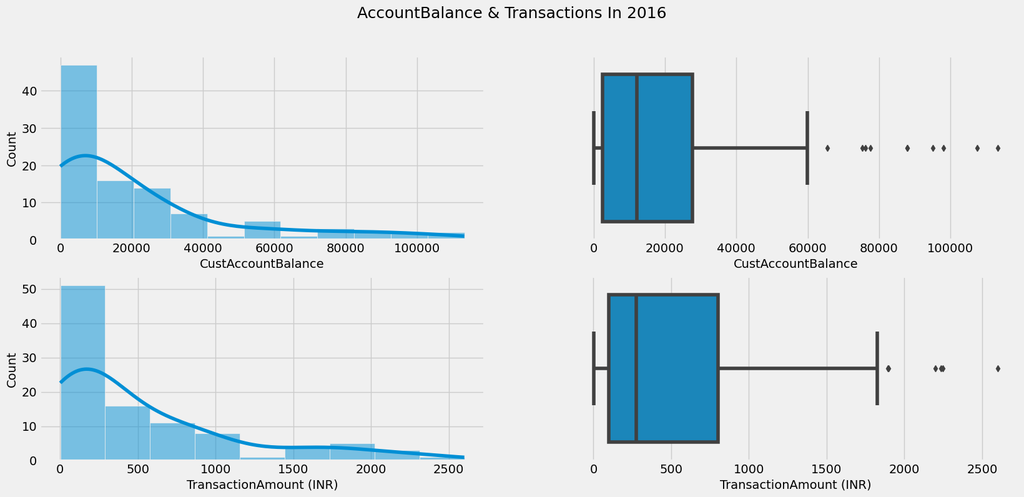

```python
# question no 2
fig, ax = plt.subplots(2, 2, figsize = (18,8))

# Set the main title of the figure
plt.suptitle('AccountBalance & Transactions In 2016', size = 18)

ax[0,0] = sns.histplot(df[0:100], x='CustAccountBalance', ax=ax[0,0], kde = True)
ax[1,0] = sns.histplot(df[0:100], x='TransactionAmount (INR)', ax=ax[1,0], kde = True)
ax[0,1] = sns.boxplot(df[0:100], x='CustAccountBalance', ax=ax[0,1], orient = 'h')
ax[1,1] = sns.boxplot(df[0:100], x='TransactionAmount (INR)', ax=ax[1,1], orient = 'h')

# Show the figure
plt.show()
```

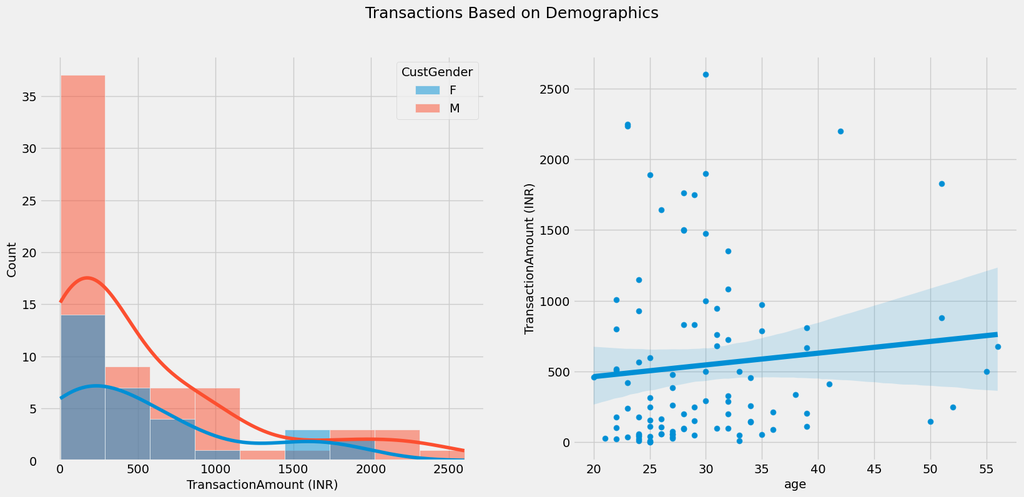

```python
# question no 2
fig, ax = plt.subplots(1,2, figsize = (18,8))

# Set the main title of the figure
plt.suptitle('Transactions Based on Demographics', size = 18)

ax[0] = sns.histplot(df[0:100], x='TransactionAmount (INR)', ax = ax[0],kde = True, hue ='CustGender')
ax[1] = sns.scatterplot(df[0:100], x='age', y='TransactionAmount (INR)',ax = ax[1])
ax[1] = sns.regplot(df[0:100], x='age', y='TransactionAmount (INR)',ax = ax[1])

# Show the figure
plt.show()
```

```python
df.info()
```

```
<class 'pandas.core.frame.DataFrame'>
Int64Index: 738110 entries, 0 to 947373
Data columns (total 6 columns):
 #   Column                   Non-Null Count   Dtype
---  ------                   --------------   -----
 0   CustGender               738110 non-null  object
 1   CustLocation             738110 non-null  object
 2   CustAccountBalance       738110 non-null  float64
 3   TransactionDate          738110 non-null  datetime64[ns]
 4   TransactionAmount (INR)  738110 non-null  float64
 5   age                      738110 non-null  float64
dtypes: datetime64[ns](1), float64(3), object(2)
memory usage: 39.4+ MB
```

```python
# Transaction trends in year 2016
df2 = df.copy()
df2.set_index('TransactionDate', inplace=True)
daily_total = df2.groupby(pd.Grouper(freq='W'))['TransactionAmount (INR)'].sum()
```

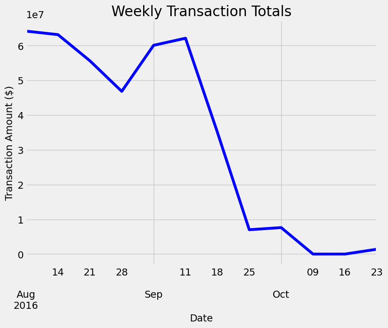

```python
fig = plt.subplots(figsize = (8, 6))

daily_total.plot(color='blue', linestyle='solid')

plt.title('Weekly Transaction Totals')
plt.xlabel('Date')
plt.ylabel('Transaction Amount ($)')
plt.show()
```

```python
df.info()
```

```
<class 'pandas.core.frame.DataFrame'>
Int64Index: 738110 entries, 0 to 947373
Data columns (total 6 columns):
 #   Column                   Non-Null Count   Dtype
---  ------                   --------------   -----
 0   CustGender               738110 non-null  object
 1   CustLocation             738110 non-null  object
 2   CustAccountBalance       738110 non-null  float64
 3   TransactionDate          738110 non-null  datetime64[ns]
 4   TransactionAmount (INR)  738110 non-null  float64
 5   age                      738110 non-null  float64
dtypes: datetime64[ns](1), float64(3), object(2)
memory usage: 39.4+ MB
```

# Data Preprocessing

```python
df2 = df.copy()
```

```python
from sklearn.preprocessing import StandardScaler

colnames = df2.columns
num_columns = df2.select_dtypes(include=['float', 'int']).columns
df2[num_columns] = StandardScaler().fit_transform(df2[num_columns])
```

```python
X = df[['CustAccountBalance', 'TransactionAmount (INR)']]
```

# Elbow Method

```python
from sklearn.cluster import KMeans
wcss = []

for i in range(1, 15):
    kmeans = KMeans(n_clusters = i, init = 'k-means++', random_state=42)
    kmeans.fit(X)
    wcss.append(kmeans.inertia_)
```

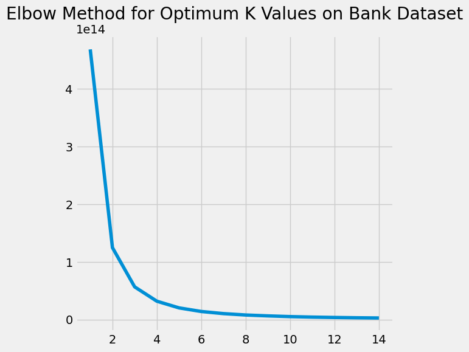

```python
fig, ax = plt.subplots(figsize = (6,6))

plt.plot(range(1,15), wcss)

plt.title('Elbow Method for Optimum K Values on Bank Dataset')

plt.show()
```

Optimum k was k = 3

Criterian for choosing the optimal clusters in elbow method:

Look for the point from where the SSE plot starts looking linear. In other words, the decrease in SSE is not much after that point.

In this case , 3 is the optimal number of cluster.

# Unsupervised Learning

```python
kmeans = KMeans(n_clusters = 3, init = 'k-means++', random_state=42)
y_kmeans = kmeans.fit_predict(X)

X['cluster'] = y_kmeans
```

```python
X1 = X[X['cluster'] == 0]
X2 = X[X['cluster'] == 1]
X3 = X[X['cluster'] == 2]
```

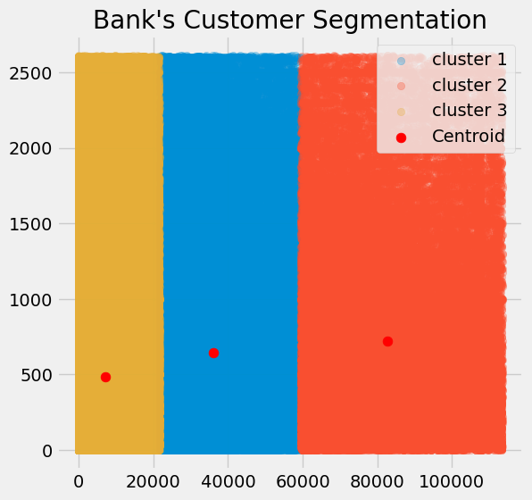

```python
fig, ax = plt.subplots(figsize = (6,6))

plt.title("Bank's Customer Segmentation")

plt.scatter(X1.iloc[:,0], X1.iloc[:, 1], label = 'cluster 1', alpha = 0.3)
plt.scatter(X2.iloc[:,0], X2.iloc[:, 1], label = 'cluster 2', alpha = 0.3)
plt.scatter(X3.iloc[:,0], X3.iloc[:, 1], label = 'cluster 3', alpha = 0.3)
plt.scatter(kmeans.cluster_centers_[:, 0], kmeans.cluster_centers_[:, 1], color = 'red',
           label = 'Centroid', s= 60)

plt.legend()
plt.show()
```

```python
df['Cluster'] = X['cluster']
```

```python
clust_count = df['Cluster'].value_counts()
```

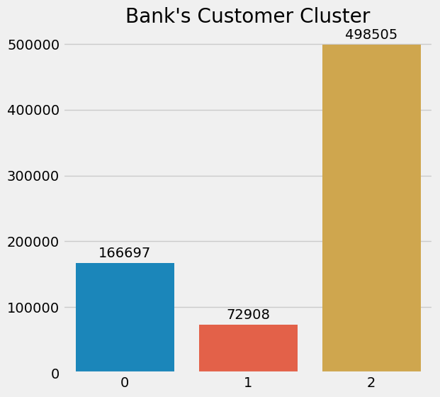

```python
fig, ax = plt.subplots(figsize = (6,6))

plt.title("Bank's Customer Cluster")

ax = sns.barplot(x = clust_count.index, y = clust_count.values)

for p in ax.patches:
    ax.annotate(format(p.get_height(), '.0f'),
                (p.get_x() + p.get_width() / 2., p.get_height()),
                ha = 'center', va = 'center',
                xytext = (0, 10),
                textcoords = 'offset points')

plt.show()
```

# Identify Bank Customer Demography from Each Cluster

```python
clust1 = df[df['Cluster'] == 0]
clust2 = df[df['Cluster'] == 1]
clust3 = df[df['Cluster'] == 2]
```

```
[Text(0, 0, 'MUMBAI'),
```

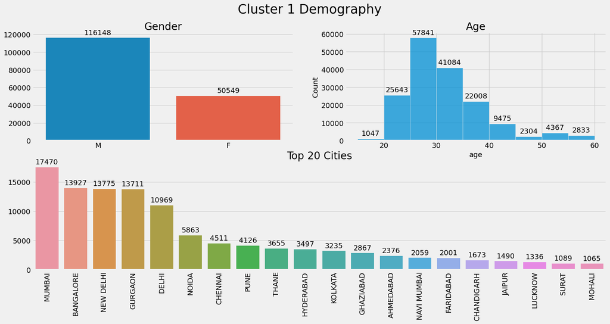

```python
# identify cluster1
fig, ax = plt.subplots(2, 2, figsize = (18,8))
bins = [15, 20, 25, 30, 35, 40, 45, 50, 55, 60]

grid_shape = (2, 2)

plt.suptitle("Cluster 1 Demography", size = 25)

ax1 = plt.subplot2grid(grid_shape, (0, 0))
ax1 = sns.barplot(x=clust1['CustGender'].value_counts().index, y = clust1['CustGender'].value_counts().values)
ax1.set_title('Gender')

ax2 = plt.subplot2grid(grid_shape, (0, 1))
ax2 = sns.histplot(clust1['age'], bins = bins)
ax2.set_title('Age')

ax3 = plt.subplot2grid(grid_shape, (1, 0), colspan=2)
ax3 = sns.barplot(x=clust1['CustLocation'].value_counts()[0:20].index, y = clust1['CustLocation'].value_counts()[0:20].values)
ax3.set_title('Top 20 Cities')


for p in ax1.patches:
    ax1.annotate(format(p.get_height(), '.0f'),
                (p.get_x() + p.get_width() / 2., p.get_height()),
                ha = 'center', va = 'center',
                xytext = (0, 10),
                textcoords = 'offset points')

for p in ax2.patches:
    ax2.annotate(format(p.get_height(), '.0f'),
                (p.get_x() + p.get_width() / 2., p.get_height()),
                ha = 'center', va = 'center',
                xytext = (0, 10),
                textcoords = 'offset points')

for p in ax3.patches:
    ax3.annotate(format(p.get_height(), '.0f'),
                (p.get_x() + p.get_width() / 2., p.get_height()),
                ha = 'center', va = 'center',
                xytext = (0, 10),
                textcoords = 'offset points')

ax3.set_xticklabels(clust1['CustLocation'].value_counts()[0:20].index, rotation=90)
```

```
[Text(0, 0, 'MUMBAI'),
```

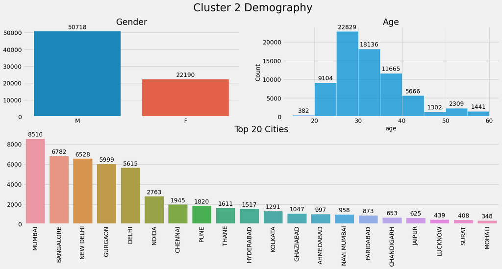

```python
# identify cluster2
fig, ax = plt.subplots(2, 2, figsize = (18,8))
bins = [15, 20, 25, 30, 35, 40, 45, 50, 55, 60]

grid_shape = (2, 2)

plt.suptitle("Cluster 2 Demography", size = 25)

ax1 = plt.subplot2grid(grid_shape, (0, 0))
ax1 = sns.barplot(x=clust2['CustGender'].value_counts().index, y = clust2['CustGender'].value_counts().values)
ax1.set_title('Gender')

ax2 = plt.subplot2grid(grid_shape, (0, 1))
ax2 = sns.histplot(clust2['age'], bins = bins)
ax2.set_title('Age')

ax3 = plt.subplot2grid(grid_shape, (1, 0), colspan=2)
ax3 = sns.barplot(x=clust2['CustLocation'].value_counts()[0:20].index, y = clust2['CustLocation'].value_counts()[0:20].values)
ax3.set_title('Top 20 Cities')

for p in ax1.patches:
    ax1.annotate(format(p.get_height(), '.0f'),
                (p.get_x() + p.get_width() / 2., p.get_height()),
                ha = 'center', va = 'center',
                xytext = (0, 10),
                textcoords = 'offset points')

for p in ax2.patches:
    ax2.annotate(format(p.get_height(), '.0f'),
                (p.get_x() + p.get_width() / 2., p.get_height()),
                ha = 'center', va = 'center',
                xytext = (0, 10),
                textcoords = 'offset points')

for p in ax3.patches:
    ax3.annotate(format(p.get_height(), '.0f'),
                (p.get_x() + p.get_width() / 2., p.get_height()),
                ha = 'center', va = 'center',
                xytext = (0, 10),
                textcoords = 'offset points')

ax3.set_xticklabels(clust1['CustLocation'].value_counts()[0:20].index, rotation=90)
```

```
[Text(0, 0, 'MUMBAI'),
```

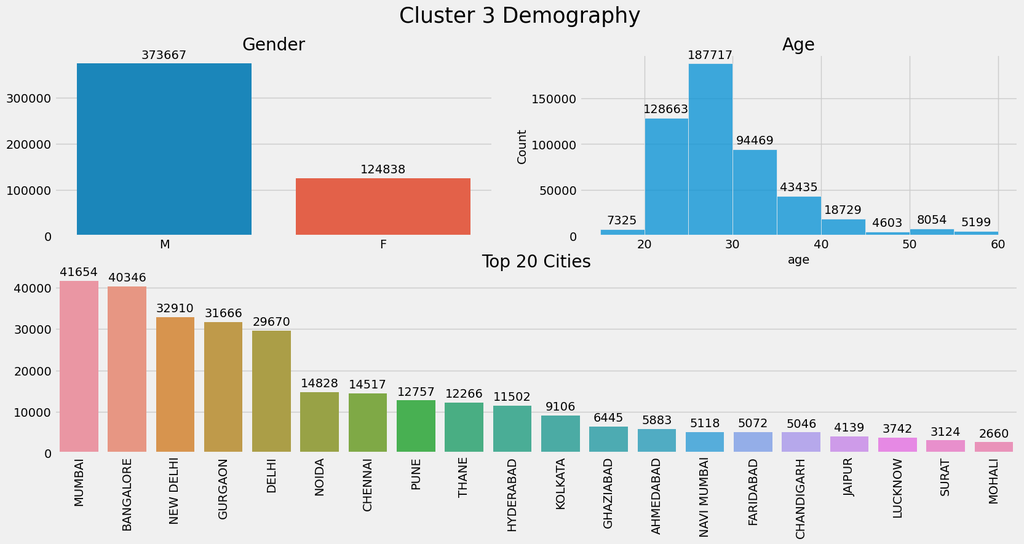

```python
# identify cluster3
fig, ax = plt.subplots(2, 2, figsize = (18,8))
bins = [15, 20, 25, 30, 35, 40, 45, 50, 55, 60]

grid_shape = (2, 2)

plt.suptitle("Cluster 3 Demography", size = 25)

ax1 = plt.subplot2grid(grid_shape, (0, 0))
ax1 = sns.barplot(x=clust3['CustGender'].value_counts().index, y = clust3['CustGender'].value_counts().values)
ax1.set_title('Gender')

ax2 = plt.subplot2grid(grid_shape, (0, 1))
ax2 = sns.histplot(clust3['age'], bins = bins)
ax2.set_title('Age')

ax3 = plt.subplot2grid(grid_shape, (1, 0), colspan=2)
ax3 = sns.barplot(x=clust3['CustLocation'].value_counts()[0:20].index, y = clust3['CustLocation'].value_counts()[0:20].values)
ax3.set_title('Top 20 Cities')


for p in ax1.patches:
    ax1.annotate(format(p.get_height(), '.0f'),
                (p.get_x() + p.get_width() / 2., p.get_height()),
                ha = 'center', va = 'center',
                xytext = (0, 10),
                textcoords = 'offset points')

for p in ax2.patches:
    ax2.annotate(format(p.get_height(), '.0f'),
                (p.get_x() + p.get_width() / 2., p.get_height()),
                ha = 'center', va = 'center',
                xytext = (0, 10),
                textcoords = 'offset points')

for p in ax3.patches:
    ax3.annotate(format(p.get_height(), '.0f'),
                (p.get_x() + p.get_width() / 2., p.get_height()),
                ha = 'center', va = 'center',
                xytext = (0, 10),
                textcoords = 'offset points')

ax3.set_xticklabels(clust1['CustLocation'].value_counts()[0:20].index, rotation=90)
```

# Conclusion

2.Further analysis by demographics, there is not much differentiation from gender and location except by age group. Specific on Young cusomters (20 - 25 year old). Where :

----Cluster 1 = Has a moderate number of young customer compared to cluster 2 & cluster 3

----Cluster 2 = Has a lowest number of young customer compared to cluster 1 & cluster 3

----Cluster 3 = Has a highest number of young customer compared to cluster 1 & cluster 2

3.This analysis could be used by marketing and product team to customize financial product that could attract for each cluster.

```python
df.info()
```

```
<class 'pandas.core.frame.DataFrame'>
Int64Index: 738110 entries, 0 to 947373
Data columns (total 7 columns):
 #   Column                   Non-Null Count   Dtype
---  ------                   --------------   -----
 0   CustGender               738110 non-null  object
 1   CustLocation             738110 non-null  object
 2   CustAccountBalance       738110 non-null  float64
 3   TransactionDate          738110 non-null  datetime64[ns]
 4   TransactionAmount (INR)  738110 non-null  float64
 5   age                      738110 non-null  float64
 6   Cluster                  738110 non-null  int32
dtypes: datetime64[ns](1), float64(3), int32(1), object(2)
memory usage: 42.2+ MB
```

```python
#Step 1: Convert 'TransactionDate' to datetime format
df['TransactionDate'] = pd.to_datetime(df['TransactionDate'])
```

```python
#Step 2: Calculate Recency, Frequency, and Monetary values
#Assume the current date as the reference date
current_date = max(df['TransactionDate'])
```

```python
# Calculate Recency as the difference between the maximum transaction date and the current date
recency = df.groupby('Cluster')['TransactionDate'].max().apply(lambda x: (current_date - x).days)
```

```python
# Calculate Frequency as the number of transactions per customer
frequency = df.groupby('Cluster').size()
```

```python
# Calculate Monetary as the total transaction amount per customer
monetary = df.groupby('Cluster')['TransactionAmount (INR)'].sum()
```

```python
# Step 3: Create the RFM DataFrame
rfm = pd.DataFrame({'Recency': recency, 'Frequency': frequency, 'Monetary': monetary})
```

```python
# Define custom bin edges for Recency
recency_bins = [-float('inf'), rfm['Recency'].quantile(0.25), rfm['Recency'].quantile(0.5), rfm['Recency'].quantile(0.75), float('inf')]
rfm['R_Score'] = np.digitize(rfm['Recency'], bins=recency_bins, right=False)

# Define custom bin edges for Frequency
frequency_bins = [-float('inf'), rfm['Frequency'].quantile(0.25), rfm['Frequency'].quantile(0.5), rfm['Frequency'].quantile(0.75), float('inf')]
rfm['F_Score'] = np.digitize(rfm['Frequency'], bins=frequency_bins, right=False)

# Define custom bin edges for Monetary
monetary_bins = [-float('inf'), rfm['Monetary'].quantile(0.25), rfm['Monetary'].quantile(0.5), rfm['Monetary'].quantile(0.75), float('inf')]
rfm['M_Score'] = np.digitize(rfm['Monetary'], bins=monetary_bins, right=False)

# Adjust labels if needed
label_mapping = {1: 1, 2: 2, 3: 3}
rfm['R_Score'] = rfm['R_Score'].map(label_mapping)
rfm['F_Score'] = rfm['F_Score'].map(label_mapping)
rfm['M_Score'] = rfm['M_Score'].map(label_mapping)
```

```python
# Combine RFM scores into a single column
rfm['RFM_Score'] = rfm['R_Score'].astype(str) + rfm['F_Score'].astype(str) + rfm['M_Score'].astype(str)

# Convert the combined score back to integer if needed
rfm['RFM_Score'] = rfm['RFM_Score']

# Display the DataFrame with the new RFM_Score column
print(rfm[['R_Score', 'F_Score', 'M_Score', 'RFM_Score']])
```

```
         R_Score  F_Score  M_Score  RFM_Score
Cluster
0            NaN      3.0      3.0  nan3.03.0
1            NaN      1.0      1.0  nan1.01.0
2            NaN      NaN      NaN  nannannan
```

```python
# Fill NaN values with a placeholder (e.g., 0)
rfm[['R_Score', 'F_Score', 'M_Score']] = rfm[['R_Score', 'F_Score', 'M_Score']].fillna(0)

# Combine RFM scores into a single column
rfm['RFM_Score'] = rfm['R_Score'].astype(int).astype(str) + rfm['F_Score'].astype(int).astype(str) + rfm['M_Score'].astype(int).astype(str)

# Display the DataFrame with the new RFM_Score column
print(rfm[['R_Score', 'F_Score', 'M_Score', 'RFM_Score']])
```

```
         R_Score  F_Score  M_Score RFM_Score
Cluster
0            0.0      3.0      3.0       033
1            0.0      1.0      1.0       011
2            0.0      0.0      0.0       000
```

```python
# Convert 'RFM_Score' to integers
rfm['RFM_Score'] = rfm['RFM_Score'].astype(int)

# Define segmentation criteria
high_value = (rfm['RFM_Score'] >= 10)  # Adjust the criteria based on your RFM score ranges
medium_value = (rfm['RFM_Score'].between(80, 100))  # Adjust the criteria based on your RFM score ranges
low_value = (rfm['RFM_Score'] <= 50)  # Adjust the criteria based on your RFM score ranges

# Create a new 'Segment' column based on segmentation criteria
rfm['Segment'] = np.select([high_value, medium_value, low_value], ['High Value', 'Medium Value', 'Low Value'], default='Other')

# Display the DataFrame with the new 'Segment' column
print(rfm[['RFM_Score', 'Segment']])
```

```
         RFM_Score     Segment
Cluster
0               33  High Value
1               11  High Value
2                0   Low Value
```

# Network analysis or Graph analysis of customer data

```python
df.info()
```

```
<class 'pandas.core.frame.DataFrame'>
Int64Index: 738110 entries, 0 to 947373
Data columns (total 7 columns):
 #   Column                   Non-Null Count   Dtype
---  ------                   --------------   -----
 0   CustGender               738110 non-null  object
 1   CustLocation             738110 non-null  object
 2   CustAccountBalance       738110 non-null  float64
 3   TransactionDate          738110 non-null  datetime64[ns]
 4   TransactionAmount (INR)  738110 non-null  float64
 5   age                      738110 non-null  float64
 6   Cluster                  738110 non-null  int32
dtypes: datetime64[ns](1), float64(3), int32(1), object(2)
memory usage: 42.2+ MB
```

```python
import networkx as nx
import matplotlib.pyplot as plt
```

```python
# Create a directed graph with weighted edges
customer_graph = nx.DiGraph()
```

```python
# Add weighted edges based on customer interactions (transactions)
for _, row in df.iterrows():
    sender = (row['CustGender'], row['CustLocation'], row['CustAccountBalance'], row['age'], row['Cluster'])
    receiver = (row['CustGender'], row['CustLocation'], row['CustAccountBalance'], row['age'], row['Cluster'])
    customer_graph.add_edge(sender, receiver, weight=row['TransactionAmount (INR)'])
```

```python
# Calculate degree centrality
degree_centrality = nx.degree_centrality(customer_graph)
```

```python
# Calculate approximate betweenness centrality
approx_betweenness_centrality = nx.betweenness_centrality(customer_graph, k=100, normalized=True, endpoints=False, seed=42)
```

```python
# Identify the most influential customers based on centrality measures
most_influential_degree = max(degree_centrality, key=degree_centrality.get)
most_influential_approx_betweenness = max(approx_betweenness_centrality, key=approx_betweenness_centrality.get)
```

```python
print("Most Influential Customer (Degree Centrality):", most_influential_degree)
print("Most Influential Customer (Approximate Betweenness Centrality):", most_influential_approx_betweenness)
```

```
Most Influential Customer (Degree Centrality): ('F', 'JAMSHEDPUR', 17819.05, 22.0, 2)
Most Influential Customer (Approximate Betweenness Centrality): ('F', 'JAMSHEDPUR', 17819.05, 22.0, 2)
```

```python
# Visualize a subset of the graph with node size proportional to degree centrality
sampled_nodes = list(customer_graph.nodes)[:100]  # Sample 100 nodes for visualization
subgraph = customer_graph.subgraph(sampled_nodes)
```

```python
# Calculate layout and visualize
pos = nx.spring_layout(subgraph)
node_size = [5000 * degree_centrality[node] for node in subgraph.nodes]
```

[figure not shown]

```python
nx.draw_networkx(subgraph, pos=pos, with_labels=True, node_size=node_size, cmap=plt.cm.Blues)
```